# Introduction

This Project is on a data set contains about 113937 loans with 81 variables on each loan.

The main purpose of this project is to summarize the characteristics btw the Loan Rate , Employee status , Loan Quater ,CreditScore among multiple variable using summary statics and data visualizations.

## Univariate Exploration

## Occupations of borrowers

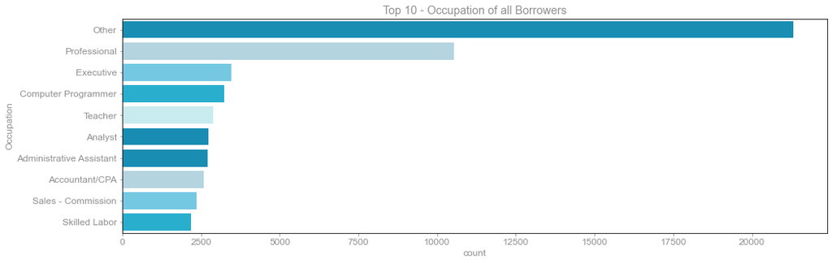

```python
# see the top 10 occupations of borrowers
plt.figure(figsize = [16, 5])

sb.countplot(data = df_loan_2, y = 'Occupation', palette = color_palette_list,
             order = df_loan_2['Occupation'].value_counts().head(10).index );
plt.title("Top 10 - Occupation of all Borrowers");
plt.savefig('Top 10 - Occupation of all Borrowers', bbox_inches='tight')
```

**Insights:**

As we can see that the number of borrowers from other field is around 21317 where as the professional are having 10542

## Current Loan Status

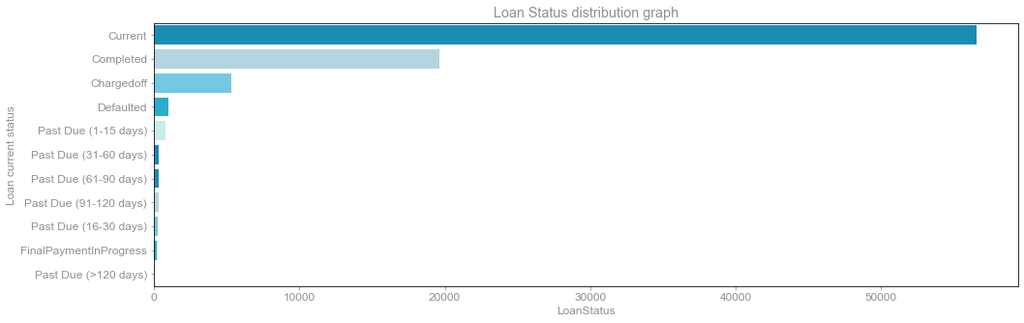

```python
# What is the loan Status?
fig, ax = plt.subplots(figsize = (16,5))
ax=sb.barplot(y=df_loan_2['LoanStatus'].value_counts().index, x=df_loan_2['LoanStatus'].value_counts(),palette = color_palette_list )
plt.title("Loan Status distribution graph");
ax.set_ylabel("Loan current status")
plt.savefig('Loan Status', bbox_inches='tight')
```

**Insights:**

- From the above graph we can say their are many loan status are in current status and few of them are completed.
- 56576 loans status are current and 19664 loan status are completed .

## Employment Status

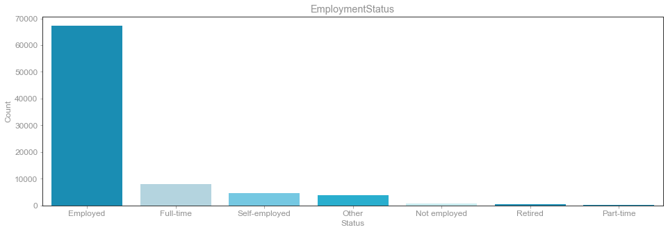

```python
fig, ax = plt.subplots(figsize = (16,5))
ax=sb.barplot(x=df_loan_2['EmploymentStatus'].value_counts().index, y=df_loan_2['EmploymentStatus'].value_counts(),palette = color_palette_list)
ax.set_title("EmploymentStatus")
ax.set_ylabel("Count")
ax.set_xlabel("Status")
plt.savefig('Employment Status', bbox_inches='tight')
```

**Insights:**

- Majority of the applicant are having employed status

## Income Rate distribution

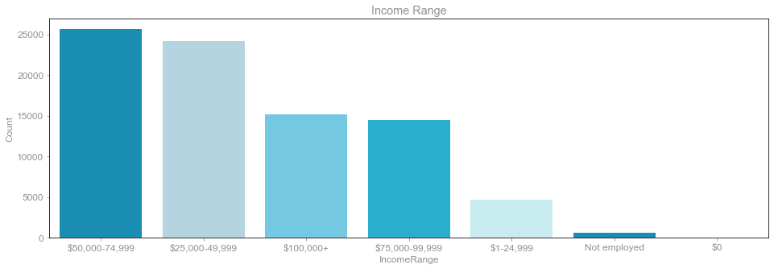

```python
fig, ax = plt.subplots(figsize = (16,5))
ax=sb.barplot(x=df_loan_2['IncomeRange'].value_counts().index, y=df_loan_2['IncomeRange'].value_counts(),palette = color_palette_list)
ax.set_title("Income Range")
ax.set_ylabel("Count")
ax.set_xlabel("IncomeRange")
plt.savefig('IncomeRange', bbox_inches='tight')
```

**Insights:**

- Majority of the loan borrower applicant have 50k to 75k income range.

## Quater in which the loan was originated

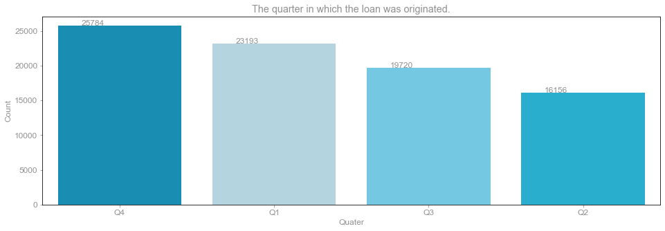

```python
fig, ax = plt.subplots(figsize = (16,5))
ax=sb.barplot(x=df_loan_2['quateryear'].value_counts().index, y=df_loan_2['quateryear'].value_counts(),palette = color_palette_list)
for p in ax.patches:
    ax.annotate('{:.0f}'.format(p.get_height()), (p.get_x()+0.15, p.get_height()+2))
ax.set_title("The quarter in which the loan was originated.")
ax.set_ylabel("Count")
ax.set_xlabel("Quater")
plt.savefig('quater', bbox_inches='tight')
```

**Insights**

- In Q4 their was max loan applicant.
- Their was a sudden drop fall after Q1 but then it started increasing .

## Loan Term

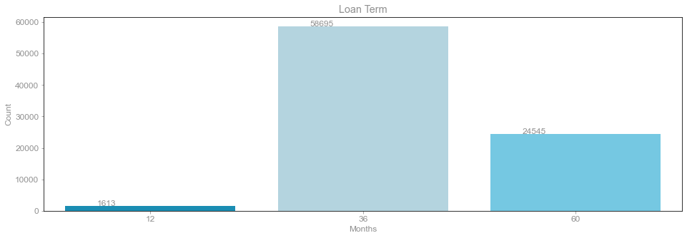

```python
fig, ax = plt.subplots(figsize = (16,5))
ax=sb.barplot(x=df_loan_2['Term'].value_counts().index, y=df_loan_2['Term'].value_counts(),palette = color_palette_list)
for p in ax.patches:
    ax.annotate('{:.0f}'.format(p.get_height()), (p.get_x()+0.15, p.get_height()+2))
ax.set_title("Loan Term")
ax.set_ylabel("Count")
ax.set_xlabel("Months")
plt.savefig('term-year', bbox_inches='tight')
```

**Insights:**

- Most of the applicant prefer to take 36 months loan terms.

## Bivariate Exploration

## Employment Status over Term

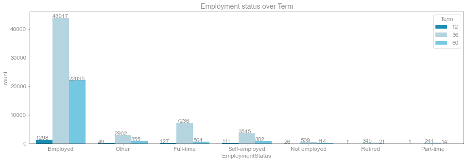

```python
fig, ax = plt.subplots(figsize = (16,5))
ax=sb.countplot(data = df_loan_2, x = 'EmploymentStatus', hue = 'Term', palette = color_palette_list)
for p in ax.patches:
    ax.annotate('{:.0f}'.format(p.get_height()), (p.get_x(), p.get_height()+2))
ax.set_title("Employment status over Term")
plt.savefig('termEmploymentstatus', bbox_inches='tight')
```

## Employment Status over Income Rate

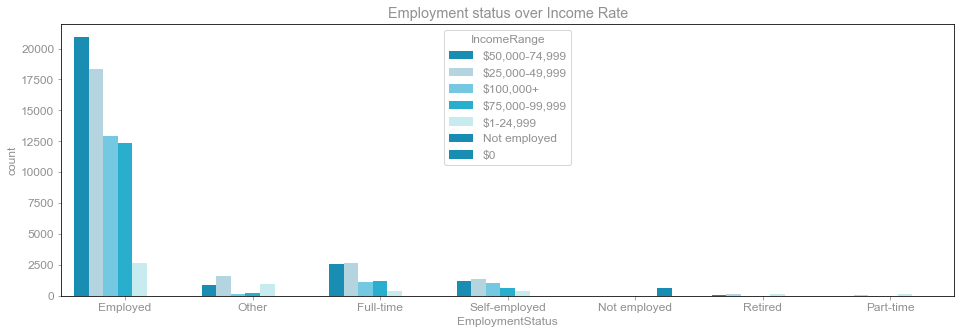

```python
fig, ax = plt.subplots(figsize = (16,5))
sb.countplot(data = df_loan_2, x = 'EmploymentStatus', hue = 'IncomeRange', palette = color_palette_list)
ax.set_title("Employment status over Income Rate")

plt.show()
```

## Analyze of No of home owner having employment status

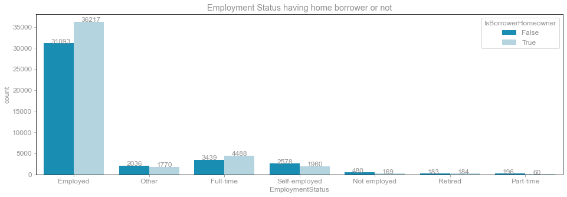

```python
fig, ax = plt.subplots(figsize = (16,5))
ax=sb.countplot(data = df_loan_2, x = 'EmploymentStatus', hue = 'IsBorrowerHomeowner', palette = color_palette_list)
for p in ax.patches:
    ax.annotate('{:.0f}'.format(p.get_height()), (p.get_x()+0.1, p.get_height()+2))
ax.set_title("Employment Status having home borrower or not")
plt.savefig('mEmploymentstatus-homeowner', bbox_inches='tight')
```

## Loan Term having on Home owner

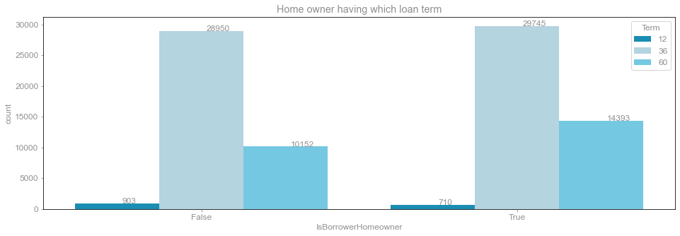

```python
fig, ax = plt.subplots(figsize = (16,5))
ax=sb.countplot(data = df_loan_2, x = 'IsBorrowerHomeowner', hue = 'Term', palette = color_palette_list)
for p in ax.patches:
    ax.annotate('{:.0f}'.format(p.get_height()), (p.get_x()+0.15, p.get_height()+2))
ax.set_title("Home owner having which loan term")

plt.savefig('Employmentstatus-Term', bbox_inches='tight')
```